# Awatson_Project_Full_Code_Notebook_EasyVisa

[figure not shown]

Data Science and Business Analytics

Ensemble Techniques and Model Tuning

[figure not shown]

Visa Approval Facilitation

# **Problem Statement**

## Context

Business communities in the United States are facing high demand for human resources, but one of the constant challenges is identifying and attracting the right talent, which is perhaps the most important element in remaining competitive. Companies in the United States look for hard-working, talented, and qualified individuals both locally as well as abroad.

The Immigration and Nationality Act (INA) of the US permits foreign workers to come to the United States to work on either a temporary or permanent basis. The act also protects US workers against adverse impacts on their wages or working conditions by ensuring US employers' compliance with statutory requirements when they hire foreign workers to fill workforce shortages. The immigration programs are administered by the Office of Foreign Labor Certification (OFLC).

OFLC processes job certification applications for employers seeking to bring foreign workers into the United States and grants certifications in those cases where employers can demonstrate that there are not sufficient US workers available to perform the work at wages that meet or exceed the wage paid for the occupation in the area of intended employment.

## Objective

In FY 2016, the OFLC processed 775,979 employer applications for 1,699,957 positions for temporary and permanent labor certifications. This was a nine percent increase in the overall number of processed applications from the previous year. The process of reviewing every case is becoming a tedious task as the number of applicants is increasing every year.

The increasing number of applicants every year calls for a Machine Learning based solution that can help in shortlisting the candidates having higher chances of VISA approval. OFLC has hired the firm EasyVisa for data-driven solutions. You as a data scientist at EasyVisa have to analyze the data provided and, with the help of a classification model:

- Facilitate the process of visa approvals.
- Recommend a suitable profile for the applicants for whom the visa should be certified or denied based on the drivers that significantly influence the case status.

## Data Description

The data contains the different attributes of employee and the employer. The detailed data dictionary is given below.

- case_id: ID of each visa application
- continent: Information of continent the employee
- education_of_employee: Information of education of the employee
- has_job_experience: Does the employee has any job experience? Y= Yes; N = No
- requires_job_training: Does the employee require any job training? Y = Yes; N = No
- no_of_employees: Number of employees in the employer's company
- yr_of_estab: Year in which the employer's company was established
- region_of_employment: Information of foreign worker's intended region of employment in the US.
- prevailing_wage: Average wage paid to similarly employed workers in a specific occupation in the area of intended employment. The purpose of the prevailing wage is to ensure that the foreign worker is not underpaid compared to other workers offering the same or similar service in the same area of employment.
- unit_of_wage: Unit of prevailing wage. Values include Hourly, Weekly, Monthly, and Yearly.
- full_time_position: Is the position of work full-time? Y = Full Time Position; N = Part Time Position
- case_status: Flag indicating if the Visa was certified or denied

## Note: This is a sample solution for the project. Projects will NOT be graded on the basis of how well the submission matches this sample solution. Projects will be graded on the basis of the rubric only.

# **Importing necessary libraries**

```python
# Installing the libraries with the specified version.
!pip install numpy==1.25.2 pandas==1.5.3 scikit-learn==1.2.2 matplotlib==3.7.1 seaborn==0.13.1 xgboost==2.0.3 -q --user
```

[output not shown]

**Note**: *After running the above cell, kindly restart the notebook kernel and run all cells sequentially from the start again.*

```python
from google.colab import drive
drive.mount('/content/drive')
```

# **Loading the dataset**

```python
import pandas as pd
import numpy as np
import matplotlib.pyplot as plt
import seaborn as sns

# To ignore warnings
import warnings
warnings.filterwarnings('ignore')

# Remove the limit from the number of displayed columns and rows.
pd.set_option("display.max_columns", None)
pd.set_option("display.max_rows", None)

df = pd.read_csv("/content/drive/MyDrive/EasyVisa/EasyVisa.csv")
```

# **Overview of the Dataset**

- Observations
- Sanity checks

```python
df.head()
```

|  | case_id | continent | education_of_employee | has_job_experience | requires_job_training | no_of_employees | yr_of_estab | region_of_employment | prevailing_wage | unit_of_wage | full_time_position | case_status |
| --- | --- | --- | --- | --- | --- | --- | --- | --- | --- | --- | --- | --- |
| 0 | EZYV01 | Asia | High School | N | N | 14513 | 2007 | West | 592.2029 | Hour | Y | Denied |
| 1 | EZYV02 | Asia | Master's | Y | N | 2412 | 2002 | Northeast | 83425.6500 | Year | Y | Certified |
| 2 | EZYV03 | Asia | Bachelor's | N | Y | 44444 | 2008 | West | 122996.8600 | Year | Y | Denied |
| 3 | EZYV04 | Asia | Bachelor's | N | N | 98 | 1897 | West | 83434.0300 | Year | Y | Denied |
| 4 | EZYV05 | Africa | Master's | Y | N | 1082 | 2005 | South | 149907.3900 | Year | Y | Certified |

```python
#checking data types
df.info()
```

```
<class 'pandas.core.frame.DataFrame'>
RangeIndex: 25480 entries, 0 to 25479
Data columns (total 12 columns):
 #   Column                 Non-Null Count  Dtype
---  ------                 --------------  -----
 0   case_id                25480 non-null  object
 1   continent              25480 non-null  object
 2   education_of_employee  25480 non-null  object
 3   has_job_experience     25480 non-null  object
 4   requires_job_training  25480 non-null  object
 5   no_of_employees        25480 non-null  int64
 6   yr_of_estab            25480 non-null  int64
 7   region_of_employment   25480 non-null  object
 8   prevailing_wage        25480 non-null  float64
 9   unit_of_wage           25480 non-null  object
 10  full_time_position     25480 non-null  object
 11  case_status            25480 non-null  object
dtypes: float64(1), int64(2), object(9)
memory usage: 2.3+ MB
```

```python
#checking for nulls
df.isnull().sum()
```

|  | 0 |
| --- | --- |
| case_id | 0 |
| continent | 0 |
| education_of_employee | 0 |
| has_job_experience | 0 |
| requires_job_training | 0 |
| no_of_employees | 0 |
| yr_of_estab | 0 |
| region_of_employment | 0 |
| prevailing_wage | 0 |
| unit_of_wage | 0 |
| full_time_position | 0 |
| case_status | 0 |

**dtype:** int64

# **Exploratory Data Analysis (EDA)**

- EDA is an important part of any project involving data.
- It is important to investigate and understand the data better before building a model with it.
- A few questions have been mentioned below which will help you approach the analysis in the right manner and generate insights from the data.
- A thorough analysis of the data, in addition to the questions mentioned below, should be done.

**Leading Questions**

What is the distribution of visa case statuses (certified vs. denied)?

1. What is the distribution of visa case statuses (certified vs. denied)?
2. How does the education level of employees impact visa approval rates?
3. Is there a significant difference in visa approval rates between employees with and without prior job experience?
4. How does the prevailing wage affect visa approval? Do higher wages lead to higher chances of approval?
5. Do certain regions in the US have higher visa approval rates compared to others?
6. How does the number of employees in a company influence visa approval? Do larger companies have a higher approval rate?
7. Are visa approval rates different across various continents of employees? Which continent has the highest and lowest approval rates?

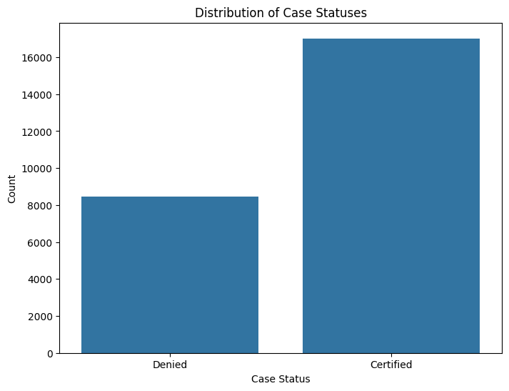

```python
#plotting distribution of a case statuses
plt.figure(figsize=(8, 6))
sns.countplot(x='case_status', data=df)
plt.title('Distribution of Case Statuses')
plt.xlabel('Case Status')
plt.ylabel('Count')
plt.show()
```

```python
#Checking how education level impacts visa approval
approval_rates = (
    df.groupby('education_of_employee')['case_status']
    .value_counts(normalize=True)
    .unstack()
    .reset_index()
)

print(approval_rates)
```

```
case_status education_of_employee  Certified    Denied
0                      Bachelor's   0.622142  0.377858
1                       Doctorate   0.872263  0.127737
2                     High School   0.340351  0.659649
3                        Master's   0.786278  0.213722
```

```python
# Calculate approval rates based on job experience
approval_rates = (
    df.groupby('has_job_experience')['case_status']
    .value_counts(normalize=True)
    .unstack()
    .reset_index()
)

print(approval_rates)
```

```
case_status has_job_experience  Certified    Denied
0                            N   0.561341  0.438659
1                            Y   0.744764  0.255236
```

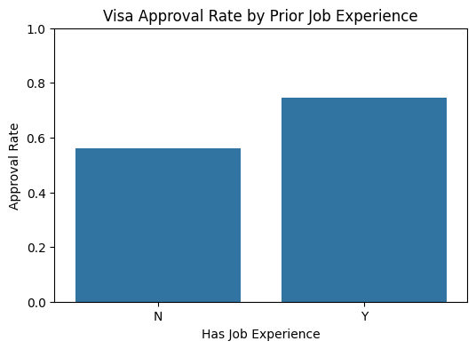

```python
plt.figure(figsize=(6,4))
sns.barplot(
    data=approval_rates,
    x='has_job_experience',
    y='Certified',
)
plt.ylabel('Approval Rate')
plt.xlabel('Has Job Experience')
plt.title('Visa Approval Rate by Prior Job Experience')
plt.ylim(0,1)
plt.show()
```

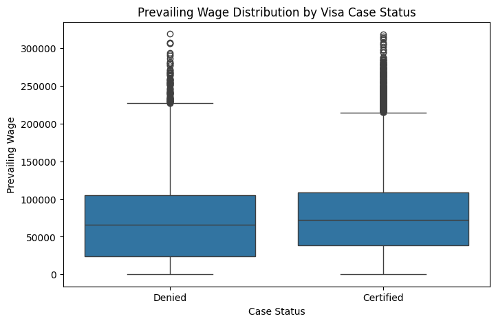

```python
#Prevailing Wage by Case Status

plt.figure(figsize=(8,5))
sns.boxplot(data=df, x='case_status', y='prevailing_wage')
plt.title('Prevailing Wage Distribution by Visa Case Status')
plt.ylabel('Prevailing Wage')
plt.xlabel('Case Status')
plt.show()
```

```python
#Wage summaries

summary = df.groupby('case_status')['prevailing_wage'].agg(['mean', 'median', 'count'])
print(summary)
```

```
                     mean    median  count
case_status
Certified    77293.619243  72486.27  17018
Denied       68748.681580  65431.46   8462
```

```
case_status region_of_employment  approval_rate
0                        Midwest       0.755282
1                          South       0.700157
2                      Northeast       0.629048
3                           West       0.622533
4                         Island       0.602667
```

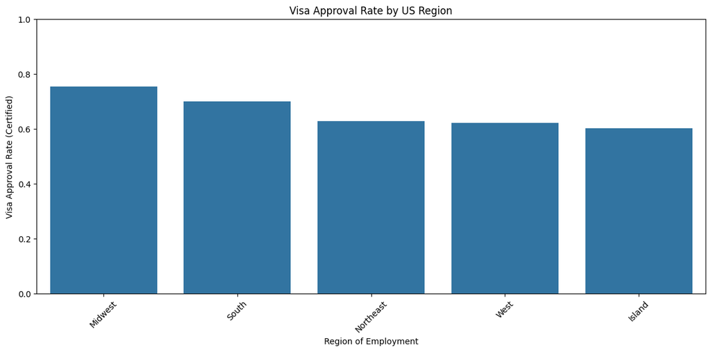

```python
# Count the number of each case_status per region
counts = df.groupby('region_of_employment')['case_status'].value_counts().unstack(fill_value=0)

# Calculating approval rate = Certified / (Certified + Denied)
counts['approval_rate'] = counts['Certified'] / (counts['Certified'] + counts['Denied'])

# Sort by approval rate descending
approval_by_region = counts.sort_values('approval_rate', ascending=False).reset_index()

print(approval_by_region[['region_of_employment', 'approval_rate']])

# Plot approval rates by region
plt.figure(figsize=(12,6))
sns.barplot(
    data=approval_by_region,
    x='region_of_employment',
    y='approval_rate',
    order=approval_by_region['region_of_employment']
)
plt.ylabel('Visa Approval Rate (Certified)')
plt.xlabel('Region of Employment')
plt.title('Visa Approval Rate by US Region')
plt.ylim(0,1)
plt.xticks(rotation=45)
plt.tight_layout()
plt.show()
```

# **Data Pre-processing**

- Missing value treatment (if needed)
- Feature engineering (if needed)
- Outlier detection and treatment (if needed)
- Preparing data for modeling
- Any other preprocessing steps (if needed)

```python
from sklearn.preprocessing import LabelEncoder

# binary columns
binary_cols = ['has_job_experience', 'requires_job_training', 'full_time_position']
for col in binary_cols:
    # mapping columns
    if col in df.columns:
        df[col] = df[col].map({'Y': 1, 'N': 0})

# One-hot encoding for multi-category columns
one_hot_cols = ['continent', 'education_of_employee', 'region_of_employment', 'unit_of_wage']
# Check if columns exist before one-hot encoding
cols_to_encode = [col for col in one_hot_cols if col in df.columns]
if cols_to_encode:
    df = pd.get_dummies(df, columns=cols_to_encode)
```

```python
#Encoding Target Variable in this case

df['case_status'] = df['case_status'].map({'Certified': 1, 'Denied': 0})
```

# **Model Building**

```python
from imblearn.over_sampling import SMOTE

# Filling NaN values in has_job_experience and requires_job_training with 0
df['has_job_experience'] = df['has_job_experience'].fillna(0)
df['requires_job_training'] = df['requires_job_training'].fillna(0)
# Fill NaN values in full_time_position with 0 after mapping
df['full_time_position'] = df['full_time_position'].fillna(0)


X = df.drop('case_status', axis=1)
y = df['case_status']

smote = SMOTE(random_state=42)
X_resampled, y_resampled = smote.fit_resample(X, y)
```

```python
#Train Test Split

from sklearn.model_selection import train_test_split

X_train, X_test, y_train, y_test = train_test_split(
    X_resampled, y_resampled, test_size=0.2, random_state=42, stratify=y_resampled
)
```

```python
#Train Model


from sklearn.ensemble import RandomForestClassifier
from sklearn.metrics import classification_report, confusion_matrix

model = RandomForestClassifier(random_state=42)
model.fit(X_train, y_train)
```

```
RandomForestClassifier(random_state=42)
```

```python
#Evaluation

y_pred = model.predict(X_test)

print(classification_report(y_test, y_pred))
print(confusion_matrix(y_test, y_pred))
```

```
              precision    recall  f1-score   support

           0       0.80      0.73      0.76      3404
           1       0.75      0.82      0.78      3404

    accuracy                           0.77      6808
   macro avg       0.77      0.77      0.77      6808
weighted avg       0.77      0.77      0.77      6808

[[2482  922]
 [ 628 2776]]
```

```python
#Feature Importance
importances = model.feature_importances_
feature_names = X_train.columns
feature_importance_df = pd.DataFrame({'feature': feature_names, 'importance': importances})
feature_importance_df = feature_importance_df.sort_values(by='importance', ascending=False)

print(feature_importance_df.head(10))
```

```
                              feature  importance
4                     prevailing_wage    0.217424
2                     no_of_employees    0.199415
3                         yr_of_estab    0.147333
14  education_of_employee_High School    0.117407
12   education_of_employee_Bachelor's    0.051892
15     education_of_employee_Master's    0.037160
20          region_of_employment_West    0.032924
7                      continent_Asia    0.029867
19         region_of_employment_South    0.029481
18     region_of_employment_Northeast    0.028761
```

# **Model Performance Improvement**

## **Note**

1. Sample parameter grids have been provided to do necessary hyperparameter tuning. These sample grids are expected to provide a balance between model performance improvement and execution time. One can extend/reduce the parameter grid based on execution time and system configuration.
- Please note that if the parameter grid is extended to improve the model performance further, the execution time will increase
2. The models chosen in this notebook are based on test runs. One can update the best models as obtained upon code execution and tune them for best performance.
- For Gradient Boosting:

```
param_grid = {
    "init": [AdaBoostClassifier(random_state=1),DecisionTreeClassifier(random_state=1)],
    "n_estimators": np.arange(50,110,25),
    "learning_rate": [0.01,0.1,0.05],
    "subsample":[0.7,0.9],
    "max_features":[0.5,0.7,1],
}
```

- For Adaboost:

```
param_grid = {
    "n_estimators": np.arange(50,110,25),
    "learning_rate": [0.01,0.1,0.05],
    "base_estimator": [
        DecisionTreeClassifier(max_depth=2, random_state=1),
        DecisionTreeClassifier(max_depth=3, random_state=1),
    ],
}
```

- For Bagging Classifier:

```
param_grid = {
    'max_samples': [0.8,0.9,1],
    'max_features': [0.7,0.8,0.9],
    'n_estimators' : [30,50,70],
}
```

- For Random Forest:

```
param_grid = {
    "n_estimators": [50,110,25],
    "min_samples_leaf": np.arange(1, 4),
    "max_features": [np.arange(0.3, 0.6, 0.1),'sqrt'],
    "max_samples": np.arange(0.4, 0.7, 0.1)
}
```

- For Decision Trees:

```
param_grid = {
    'max_depth': np.arange(2,6),
    'min_samples_leaf': [1, 4, 7],
    'max_leaf_nodes' : [10, 15],
    'min_impurity_decrease': [0.0001,0.001]
}
```

- For XGBoost:

```
param_grid={'n_estimators':np.arange(50,110,25),
            'scale_pos_weight':[1,2,5],
            'learning_rate':[0.01,0.1,0.05],
            'gamma':[1,3],
            'subsample':[0.7,0.9]
}
```

```python
from sklearn.model_selection import GridSearchCV

#Defining the parameter grid
param_grid = {
    "n_estimators": [50,110,25],
    "min_samples_leaf": np.arange(1, 4),
    "max_features": [np.arange(0.3, 0.6, 0.1),'sqrt'],
    "max_samples": np.arange(0.4, 0.7, 0.1)
}


# Initialize the Random Forest model
rf = RandomForestClassifier(random_state=42)

# Set up GridSearchCV
grid_search = GridSearchCV(
    estimator=rf,
    param_grid=param_grid,
    cv=5,                    # 5-fold cross-validation
    scoring='f1',            # Use F1-score for imbalanced data
    n_jobs=-1,               # Use all available cores
    verbose=2
)

# Fit to your training data
grid_search.fit(X_train, y_train)

# Best parameters and best score
print("Best parameters found: ", grid_search.best_params_)
print("Best F1-score: ", grid_search.best_score_)

# Use the best estimator for predictions
best_rf = grid_search.best_estimator_
y_pred = best_rf.predict(X_test)
```

```
Fitting 5 folds for each of 54 candidates, totalling 270 fits
Best parameters found:  {'max_features': 'sqrt', 'max_samples': np.float64(0.6), 'min_samples_leaf': np.int64(3), 'n_estimators': 110}
Best F1-score:  0.8032965523268928
```

```python
#Hyper Tuned Model Eval
y_pred = best_rf.predict(X_test)
print(classification_report(y_test, y_pred))
print(confusion_matrix(y_test, y_pred))
```

```
              precision    recall  f1-score   support

           0       0.84      0.71      0.77      3404
           1       0.75      0.87      0.81      3404

    accuracy                           0.79      6808
   macro avg       0.80      0.79      0.79      6808
weighted avg       0.80      0.79      0.79      6808

[[2420  984]
 [ 445 2959]]
```

```python
importances = best_rf.feature_importances_
feature_names = X_train.columns
feature_importance_df = pd.DataFrame({'feature': feature_names, 'importance': importances})
feature_importance_df = feature_importance_df.sort_values(by='importance', ascending=False)
print(feature_importance_df.head(10))
```

```
                              feature  importance
14  education_of_employee_High School    0.217193
4                     prevailing_wage    0.119314
12   education_of_employee_Bachelor's    0.095011
2                     no_of_employees    0.089354
3                         yr_of_estab    0.073442
20          region_of_employment_West    0.055494
15     education_of_employee_Master's    0.055075
18     region_of_employment_Northeast    0.048622
7                      continent_Asia    0.048259
19         region_of_employment_South    0.045117
```

# **Model Comparison and Final Model Selection**

```python
from sklearn.metrics import roc_auc_score

#Hyper Tuned Model Eval
print("Hyper Tuned Model")
y_pred = best_rf.predict(X_test)
print(classification_report(y_test, y_pred))
print("ROC-AUC:", roc_auc_score(y_test, y_pred))
print(confusion_matrix(y_test, y_pred))

#Baseline Model Eval
print("Baseline Model")
y_pred = model.predict(X_test)
print(classification_report(y_test, y_pred))
print("ROC-AUC:", roc_auc_score(y_test, y_pred))
```

```
Hyper Tuned Model
              precision    recall  f1-score   support

           0       0.84      0.71      0.77      3404
           1       0.75      0.87      0.81      3404

    accuracy                           0.79      6808
   macro avg       0.80      0.79      0.79      6808
weighted avg       0.80      0.79      0.79      6808

ROC-AUC: 0.7900998824911868
[[2420  984]
 [ 445 2959]]
Baseline Model
              precision    recall  f1-score   support

           0       0.80      0.73      0.76      3404
           1       0.75      0.82      0.78      3404

    accuracy                           0.77      6808
   macro avg       0.77      0.77      0.77      6808
weighted avg       0.77      0.77      0.77      6808

ROC-AUC: 0.7723266745005876
```

# **Actionable Insights and Recommendations**

- **Education Level is Critical:** Applicants with a "High School" education level are most strongly associated with visa certification/denial decisions in the tuned model. EasyVisa and OFLC should pay special attention to how education credentials are evaluated and possibly refine guidelines around this factor.
- **Prevailing Wage Remained Important:** The wage offered to the applicant is a strong predictor. Employers should ensure they offer competitive wages to improve certification chance.
- **Company Size and Age Matter:** Both number of employees and company age are consistently important.
- Focus on offering competitive wages and clearly documenting the necessity for foreign workers, especially if your company is small or newly established.
- Highlight applicants with higher education levels, as these profiles are more likely to be certified.
- Be aware of regional trends—some regions may have stricter scrutiny or different labor market conditions.

```python
#Converting notebook to html
from google.colab import files
! jupyter nbconvert --to html '/content/drive/MyDrive/Recell_LinearR_Data/Copy_of_SLF_Project_LearnerNotebook_FullCodeAWatson_LR.ipynb'
files.download('/content/drive/MyDrive/Recell_LinearR_Data/Copy_of_SLF_Project_LearnerNotebook_FullCodeAWatson_LR.html')
```